# H1_PVT_RunIn_20210206

#### 分析人員: Peter Lin

#### 分析日期: 2021/2/6

#### 資料來源: RunIn測試電腦(TYM899103-H1)裡的PVT csv & log檔案

### 數據初步分析總結:

1. 根據SW ENG Vic & Ken提供的問題可能發生原因訊息,並從log 資料統計判斷PVT有98.6%是初始狀態不正確或comm port連線有問題, 真正溫度量測數值超標者僅34筆數據,約佔所有測試數據的1.4%。
2. 初始狀態不正確主要原因有:SN,FW版本讀不到,FW版本錯誤,或誤操作 有關。comm port連線問題則與Y-cable的接線穩定性有關。
3. 溫度量測數值超標34筆,有4筆大於50.8C,30筆小於49.8C,且大多與 規格僅差+/-0.2C。
4. 溫度量測數值超標34筆,發生在#2 bullet有11筆(32.4%),發生在#4 bullet有7筆(20.6%),溫度量測數值超標與bullet有關。
5. 此次10個bullet,2個標準品(經外校確認),其他8個則與標準品進行 比對,其誤差約為0.2-0.3C,此誤差仍有機會造成RunIn測試因誤判而 須重測的問題,需討論是否可請客戶放寬標準或測試前進行溫度補償 的可行性或改良bullet製作的方法。

#### PVT RunIn First_Fail 資料統計分析

Total 統計

| FIRST_FAIL | 個數 | 百分比 |
| --- | --- | --- |
|  | 1573 | 65.54 |
| FixtureInit | 404 | 16.83 |
| USB_COMM | 381 | 15.88 |
| Heating | 38 | 1.58 |
| Holding | 4 | 0.17 |

依日期統計

| FIRST_FAIL | 個數 | 百分比 |
| --- | --- | --- |
| **2021/2/1** |  |  |
|  | 393 | 58.14 |
| FixtureInit | 161 | 23.82 |
| USB_COMM | 114 | 16.86 |
| Heating | 8 | 1.18 |
| **2021/2/2** |  |  |
|  | 434 | 62.00 |
| USB_COMM | 161 | 23.00 |
| FixtureInit | 93 | 13.29 |
| Heating | 10 | 1.43 |
| Holding | 2 | 0.29 |
| **2021/2/3** |  |  |
|  | 517 | 85.17 |
| FixtureInit | 45 | 7.41 |
| USB_COMM | 36 | 5.93 |
| Heating | 7 | 1.15 |
| Holding | 2 | 0.33 |
| **2021/2/4** |  |  |
|  | 224 | 57.14 |
| FixtureInit | 90 | 22.96 |
| USB_COMM | 65 | 16.58 |
| Heating | 13 | 3.32 |
| **2021/2/5** |  |  |
| FixtureInit | 15 | 60.00 |
|  | 5 | 20.00 |
| USB_COMM | 5 | 20.00 |

FixtureInit Fail 統計

| FIRST_FAIL | SN | FW_VERSION | 個數 | 百分比 |
| --- | --- | --- | --- | --- |
| **2021/2/1** |  |  |  |  |
| FixtureInit |  |  | 150 | 93.17 |
| FixtureInit |  | H1.026.PVT1.N0.20210128 | 3 | 1.86 |
| FixtureInit | OK |  | 4 | 2.48 |
| FixtureInit | OK | H1.025.PVT1.N0.20210126 | 2 | 1.24 |
| FixtureInit | OK | H1.026.PVT1.N0.20210128 | 2 | 1.24 |
| **2021/2/2** |  |  |  |  |
| FixtureInit |  |  | 88 | 94.62 |
| FixtureInit |  | H1.026.PVT1.N0.20210128 | 4 | 4.30 |
| FixtureInit | OK | H1.026.PVT1.N0.20210128 | 1 | 1.08 |
| **2021/2/3** |  |  |  |  |
| FixtureInit |  |  | 30 | 66.67 |
| FixtureInit |  | H1.026.PVT1.N0.20210128 | 3 | 6.67 |
| FixtureInit | OK | H1.026.PVT1.N0.20210128 | 12 | 26.67 |
| **2021/2/4** |  |  |  |  |
| FixtureInit |  |  | 82 | 91.11 |
| FixtureInit |  | H1.026.PVT1.N0.20210128 | 2 | 2.22 |
| FixtureInit | OK | H1.025.PVT1.N0.20210126 | 1 | 1.11 |
| FixtureInit | OK | H1.026.PVT1.N0.20210128 | 5 | 5.56 |
| **2021/2/5** |  |  |  |  |
| FixtureInit |  |  | 10 | 66.67 |
| FixtureInit | OK |  | 5 | 33.33 |

USB_COMM Fail 統計

| FIRST_FAIL | SN | FW_VERSION | 個數 | 百分比 |
| --- | --- | --- | --- | --- |
| **2021/2/1** |  |  |  |  |
| USB_COMM |  |  | 49 | 42.98 |
| USB_COMM | OK |  | 50 | 43.86 |
| USB_COMM | OK | H1.025.PVT1.N0.20210126 | 5 | 4.39 |
| USB_COMM | OK | H1.026.PVT1.N0.20210128 | 5 | 4.39 |
| USB_COMM | OK | usb rec | 5 | 4.39 |
| **2021/2/2** |  |  |  |  |
| USB_COMM |  |  | 118 | 73.29 |
| USB_COMM | OK |  | 15 | 9.32 |
| USB_COMM | OK | H1.025.PVT1.N0.20210126 | 5 | 3.11 |
| USB_COMM | OK | H1.026.PVT1.N0.20210128 | 14 | 8.70 |
| USB_COMM | OK | usb rec | 9 | 5.59 |
| **2021/2/3** |  |  |  |  |
| USB_COMM |  |  | 19 | 52.78 |
| USB_COMM | OK |  | 1 | 2.78 |
| USB_COMM | OK | H1.025.PVT1.N0.20210126 | 5 | 13.89 |
| USB_COMM | OK | H1.026.PVT1.N0.20210128 | 11 | 30.56 |
| **2021/2/4** |  |  |  |  |
| USB_COMM |  |  | 32 | 49.23 |
| USB_COMM | OK | H1.025.PVT1.N0.20210126 | 31 | 47.69 |
| USB_COMM | OK | H1.026.PVT1.N0.20210128 | 2 | 3.08 |
| **2021/2/5** |  |  |  |  |
| USB_COMM | OK |  | 5 | 100.00 |

Heating Fail 統計

| FIRST_FAIL | SN | FW_VERSION | 個數 | 百分比 |
| --- | --- | --- | --- | --- |
| **2021/2/1** |  |  |  |  |
| Heating |  | H1.026.PVT1.N0.20210128 | 5 | 62.5 |
| Heating | OK | H1.026.PVT1.N0.20210128 | 3 | 37.5 |
| **2021/2/2** |  |  |  |  |
| Heating |  | H1.026.PVT1.N0.20210128 | 3 | 30.0 |
| Heating | OK | H1.026.PVT1.N0.20210128 | 7 | 70.0 |
| **2021/2/3** |  |  |  |  |
| Heating | OK | H1.026.PVT1.N0.20210128 | 7 | 100.0 |
| **2021/2/4** |  |  |  |  |
| Heating | OK | H1.026.PVT1.N0.20210128 | 13 | 100.0 |

Holding Fail 統計

| FIRST_FAIL | SN | FW_VERSION | 個數 | 百分比 |
| --- | --- | --- | --- | --- |
| **2021/2/2** |  |  |  |  |
| Holding | OK | H1.026.PVT1.N0.20210128 | 2 | 100 |
| **2021/2/3** |  |  |  |  |
| Holding | OK | H1.026.PVT1.N0.20210128 | 2 | 100 |

#### 30台加熱溫度不足(<49.8C), 4台加熱溫度過高(>50.8C)列表

|  | d | TEST_DURATION | DUT_TEST_RESULT | FIRST_FAIL | FixtureInit | USB_COMM | Heating | Holding |
| --- | --- | --- | --- | --- | --- | --- | --- | --- |
| 1 | 2021-02-04 | 372.5063643 | FAIL | Heating | CSN: IM0100000988 | DUT Position: 2 | Heating Time:N/A : Start Temp:23.204 : Ramp Rate:-30.289 | Max Temp:49.741 : Min Temp:49.737 : Mean Temp:49.738 |
| 2 | 2021-02-04 | 361.071848 | FAIL | Heating | CSN: IM0100001016 | DUT Position: 2 | Heating Time:N/A : Start Temp:29.204 : Ramp Rate:-30.048 | Max Temp:49.788 : Min Temp:49.783 : Mean Temp:49.784 |
| 3 | 2021-02-04 | 357.9123018 | FAIL | Heating | CSN: IM0100000727 | DUT Position: 4 | Heating Time:N/A : Start Temp:25.876 : Ramp Rate:-30.684 | Max Temp:49.619 : Min Temp:49.617 : Mean Temp:49.618 |
| 4 | 2021-02-04 | 436.1183646 | FAIL | Heating | CSN: IM0100000938 | DUT Position: 8 | Heating Time:N/A : Start Temp:21.085 : Ramp Rate:-30.879 | Max Temp:49.720 : Min Temp:49.719 : Mean Temp:49.719 |
| 5 | 2021-02-04 | 419.9151077 | FAIL | Heating | CSN: IM0100001015 | DUT Position: 4 | Heating Time:N/A : Start Temp:22.893 : Ramp Rate:-30.204 | Max Temp:49.145 : Min Temp:49.136 : Mean Temp:49.138 |
| 6 | 2021-02-04 | 364.66 | FAIL | Heating | CSN: IM0100000621 | DUT Position: 4 | Heating Time:N/A : Start Temp:22.037 : Ramp Rate:-30.465 | Max Temp:48.850 : Min Temp:48.844 : Mean Temp:48.847 |
| 7 | 2021-02-04 | 372.63 | FAIL | Heating | CSN: IM0100001016 | DUT Position: 4 | Heating Time:N/A : Start Temp:22.302 : Ramp Rate:-30.369 | Max Temp:49.077 : Min Temp:49.070 : Mean Temp:49.073 |
| 8 | 2021-02-04 | 377.7311801 | FAIL | Heating | CSN: IM0100000979 | DUT Position: 8 | Heating Time:N/A : Start Temp:22.297 : Ramp Rate:-30.158 | Max Temp:49.741 : Min Temp:49.737 : Mean Temp:49.738 |
| 9 | 2021-02-04 | 379.121194 | FAIL | Heating | CSN: IM0100000938 | DUT Position: 4 | Heating Time:N/A : Start Temp:22.132 : Ramp Rate:-30.614 | Max Temp:48.536 : Min Temp:48.531 : Mean Temp:48.533 |
| 10 | 2021-02-04 | 370.513145 | FAIL | Heating | CSN: IM0100000700 | DUT Position: 4 | Heating Time:N/A : Start Temp:22.832 : Ramp Rate:-30.347 | Max Temp:48.864 : Min Temp:48.836 : Mean Temp:48.842 |

[output cut: 24 more lines]

#### 10個bullet performance 比較

Heating & Holding Fail數量加總比較

| DUT_POSITION | HeatingHoldingFail | 百分比 |
| --- | --- | --- |
| 2 | 11 | 32.35 |
| 4 | 7 | 20.59 |
| 1 | 3 | 8.82 |
| 6 | 3 | 8.82 |
| 8 | 3 | 8.82 |
| 7 | 2 | 5.88 |
| 9 | 2 | 5.88 |
| 10 | 2 | 5.88 |
| 3 | 1 | 2.94 |

RunIn測試PASS數量加總比較

| DUT_POSITION | RunIn_PASS | 百分比 |
| --- | --- | --- |
| 5 | 175 | 11.13 |
| 1 | 174 | 11.06 |
| 6 | 168 | 10.68 |
| 9 | 166 | 10.55 |
| 7 | 164 | 10.43 |
| 8 | 161 | 10.24 |
| 10 | 153 | 9.73 |
| 4 | 149 | 9.47 |
| 2 | 146 | 9.28 |
| 3 | 117 | 7.44 |

RunIn測試PASS數據之平均Holding溫度比較

| DUT_POSITION | mean_temp | total_mean_temp | 差異 |
| --- | --- | --- | --- |
| 2 | 50.11 | 50.20 | -0.09 |
| 1 | 50.15 | 50.20 | -0.05 |
| 3 | 50.17 | 50.20 | -0.03 |
| 6 | 50.18 | 50.20 | -0.02 |
| 9 | 50.20 | 50.20 | 0.00 |
| 5 | 50.21 | 50.20 | 0.01 |
| 7 | 50.22 | 50.20 | 0.02 |
| 4 | 50.23 | 50.20 | 0.03 |
| 8 | 50.25 | 50.20 | 0.05 |
| 10 | 50.28 | 50.20 | 0.08 |

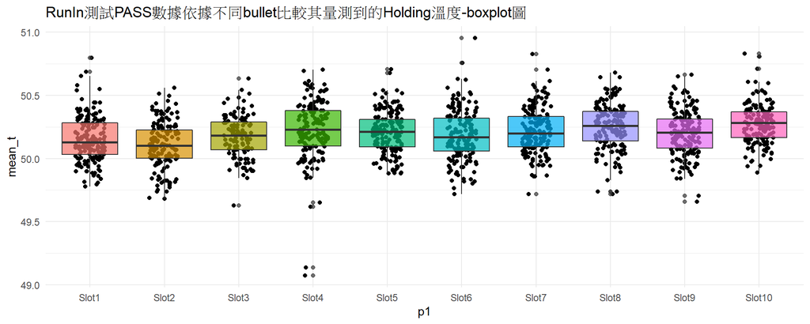

#### H1 PVT RunIn溫度曲線圖

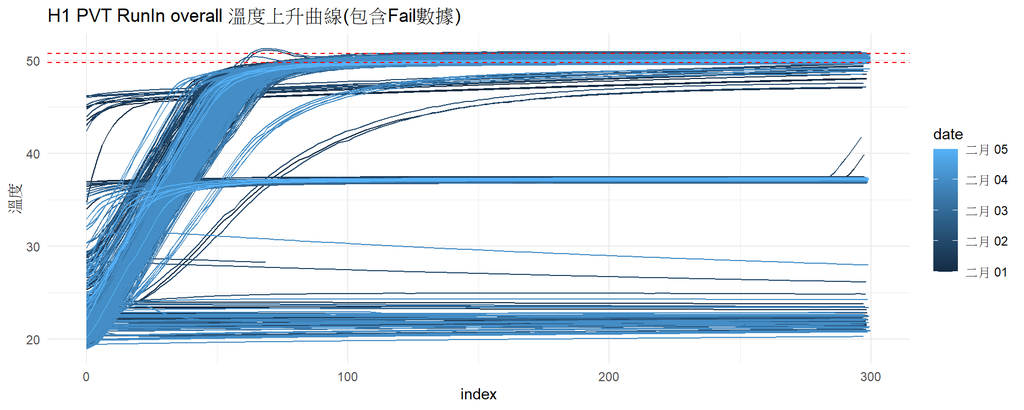

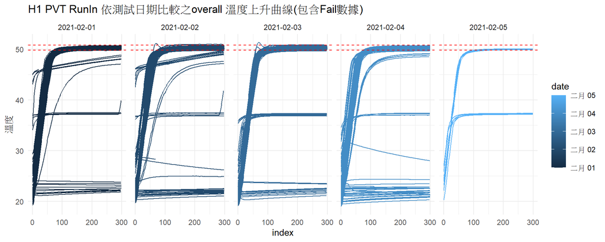

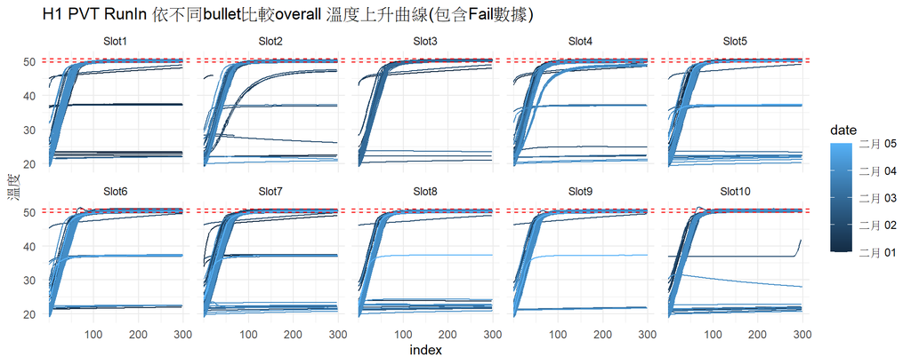

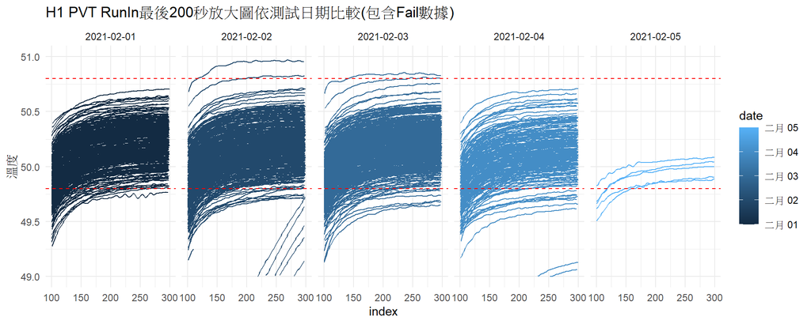

#### 刪除初始狀態NG資料後的RunIn溫度曲線圖

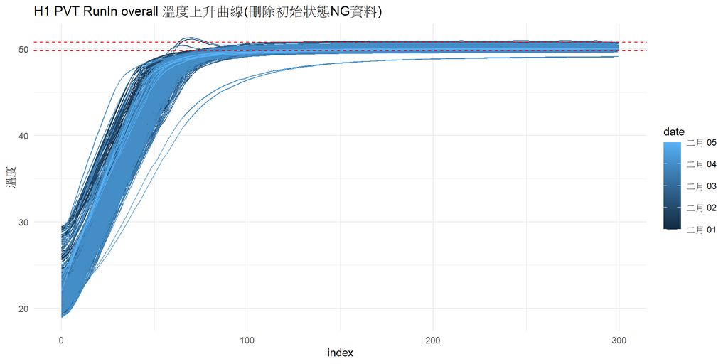

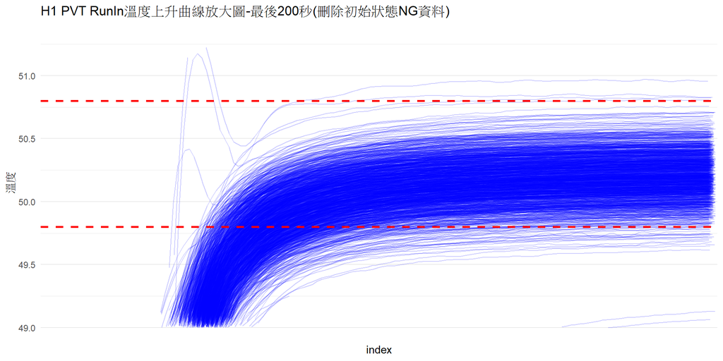

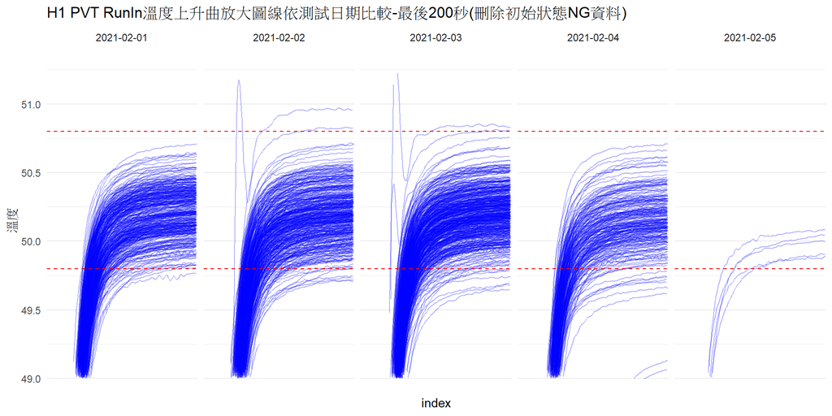

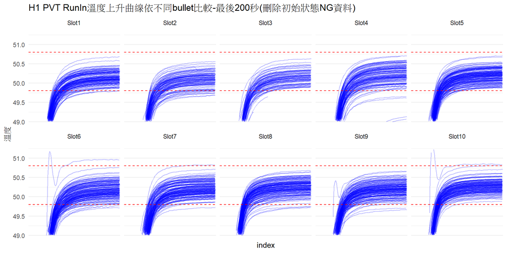

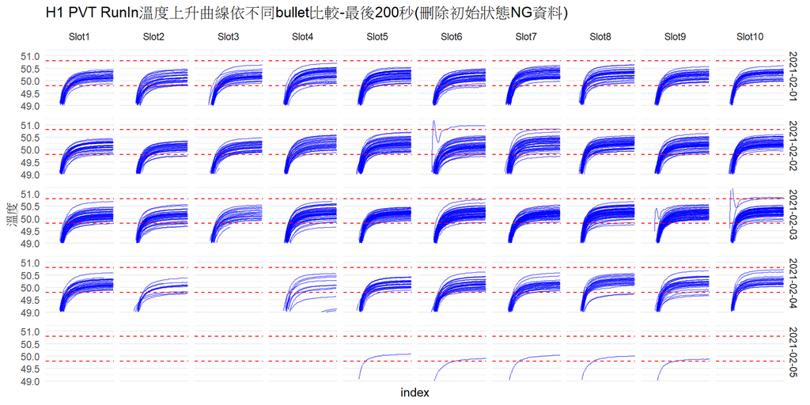